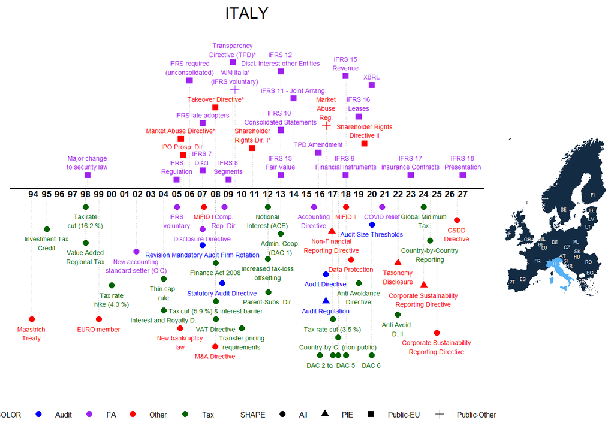

Notes: The graph depicts major regulatory changes that we identified via an extensive literature search, an online survey of mentioned authors, and other sources. Please note that the graph does not include all possible regulatory changes, e.g. minor revisions to local GAAP or tax rate changes below 3% are not included. The dates of EU Directives are based on the official transposition deadlines unless denoted with a *, in which case we included the entry-to-force date as identified in the literature. For more information, please go to [Labro and Pierk (2023)](http://www.eu-regulations.com/Labro_Pierk_2023.pdf). We kindly ask that you cite the paper if you use the information on this website in your research project. Do you have comments or see anything missing? Please email us!

## Regulations, Publications, Further Graphs

The tab ‘Regulations’ includes links to the regulations, gives short descriptions, and provides selective papers for further reading. If the regulation is a national transposition of an EU Directive, the link to the Directive is given. The tab ‘Number of Regulations’ shows graphically the number of regulations 8 years around the respective year (-4,-3,-2,-1,0,+1,+2,+3). The tab ‘Number of Categories” shows graphically the number of different categories 8 years around the respective year (-4,-3,-2,-1,0,+1,+2,+3). The tab ’Publications’ shows all publications that include the countries’ names and variations thereof in the title, abstract, or keywords. Similarly, the tab ‘SSRN’ shows papers of the SSRN Accouning Research Network that include the countries’ names and variations.

### Regulations

|  | Date | Milestones | Applies_to | Category | Description |
| --- | --- | --- | --- | --- | --- |
| 1 | 1993-11-01 | Maastricht Treaty | Public-EU | FA | Maastricht Treaty: Signed 'Treaty on European Union". |
| 2 | 1995-01-01 | Investment Tax Credit | All Firms | Tax | Investment Tax Credit: Introduction of a temporary investment credit. The credit could be carried forward up to five years and amounted to 50% of the investment in 1995 in excess of the average over t… |
| 3 | 1998-01-01 | Tax rate cut (16.2 %) | All Firms | Tax | Tax rate cut (16.2 %): Italy reduced the corporate tax rate by 16.2 percentage points (from 53.2 to 37 percent). |
| 4 | 1998-01-01 | Value Added Regional Tax | All Firms | Tax | Value Added Regional Tax: Introduction of a flat-rate tax levied on the value added generated by all types of business activities See also: Bernasconi, Marenzi and Pagani 2005; Bordignon, Gianni and P… |
| 5 | 1998-02-24 | Major change to security law | Public-EU | FA | Decreto Legislativo del 24 febbraio 1998, n. 58 (Testo unico delle disposizioni in materia di intermediazione finanziaria) (Legislative Decree No. 58 of Feb. 24, 1998 (Consolidated Law on Financial In… |
| 6 | 1999-01-01 | Euro member | All Firms | FA | Euro member: Euro area member since 1 January 1999. |
| 7 | 2000-01-01 | Tax rate hike (4.3 %) | All Firms | Tax | Tax rate increase (4.3 %): Italy increased the corporate tax rate by 4.25 percentage points (from 37 to 41.25 percent). |
| 8 | 2001-11-27 | New Accounting Standard Setter (OIC) | All Firms | FA | New accounting standard setter (OIC): Establishement of the Italian Accounting Committee OIC (Organismo Italiano di Contabilità or OIC) |
| 9 | 2004-01-01 | Thin cap. rule | All Firms | Tax | Thin cap. rule: Introduction of thin capitalization rules (limitation of tax deductibility of interest paid to shareholder). Replaced in 2008 by an interest barrier. See also: Maßbaum and Sureth 2009 |
| 10 | 2004-01-01 | Interest and Royalty D. | All Firms | Tax | Attuazione della direttiva 2003/49/CE concernente il regime fiscale applicabile ai pagamenti di interessi e di canoni fra societa' consociate di Stati membri diversi. (Implementation of Directive 2003… |

[output cut: 64 more lines]

### Number of Regulations

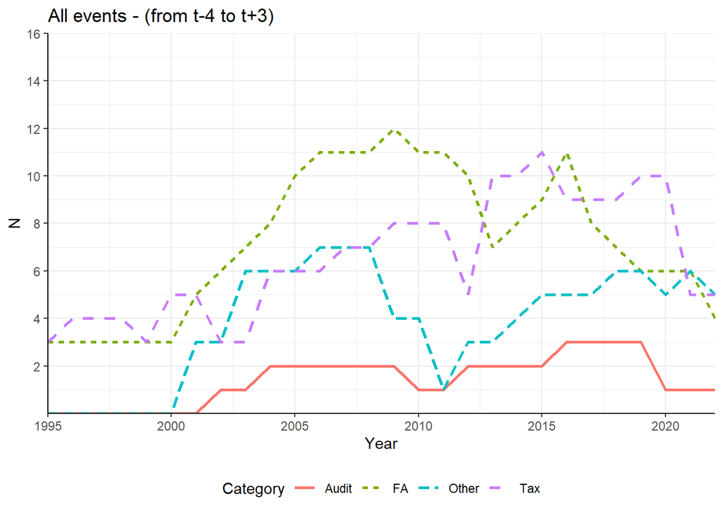

### Number of Categories

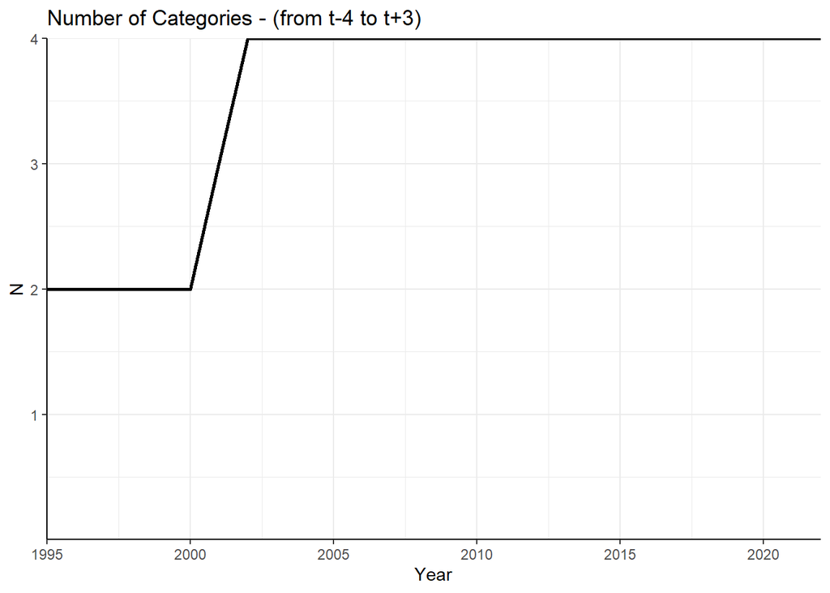

### Publications

|  | authors | title | year | journal |
| --- | --- | --- | --- | --- |
| 1 | Achilli G., Busco C., Giovannoni E. | accounting for the “transcendent self”: spirituality, narcissism, testimony and gift | 2021 | Accounting, Auditing and Accountability Journal |
| 2 | Agostini M., Costa E., Korca B. | non-financial disclosure and corporate financial performance under directive 2014/95/eu: evidence from italian listed companies | 2021 | Accounting in Europe |
| 3 | Antonelli V., Bigoni M., Funnell W., Cafaro E.M. | accounting for biosecurity in italy under covid-19 lockdown | 2021 | Accounting, Auditing and Accountability Journal |
| 4 | Antonelli V., Coronella S., Cordery C., Verona R. | accounting and governance in the final years of the papal states: dual roles in the papacy of pius ix (1846–1870) | 2021 | British Accounting Review |
| 5 | Bigoni M., Funnell W., Deidda Gagliardo E., Pierotti M. | accounting for control of italian culture in the fascist ethical state: the alla scala opera house | 2021 | Accounting, Auditing and Accountability Journal |
| 6 | Bigoni M., Maran L., Ferramosca S. | time, space and accounting at nonantola abbey (1350–1449) | 2021 | British Accounting Review |
| 7 | Bonsón E., Lavorato D., Lamboglia R., Mancini D. | artificial intelligence activities and ethical approaches in leading listed companies in the european union | 2021 | International Journal of Accounting Information Systems |
| 8 | Buchetti B., Parbonetti A., Pugliese A. | covid-19, corporate survival and public policy: the role of accounting information and regulation in the wake of a systemic crisis | 2021 | Journal of Accounting and Public Policy |
| 9 | Carungu J., Di Pietra R., Molinari M. | the impact of a humanitarian disaster on the working approach of accountants: a study of contingent effects | 2021 | Accounting, Auditing and Accountability Journal |
| 10 | Carungu J., Molinari M. | the “accountant” stereotype in the florentine medieval popular culture: “galantuomini” or usurers? | 2021 | Accounting, Auditing and Accountability Journal |

[output cut: 116 more lines]

### SSRN

|  | authors | title | Posted | Revised |
| --- | --- | --- | --- | --- |
| 1 | Andrea Albarea, Michele Bernasconi, Anna Marenzi and Dino Rizzi | tax evasion, behavioral microsimulation models and flat-rate tax reforms. analysis for italy | 2021-11-24 |  |
| 2 | H. David Rosenbloom and Fadi Shaheen | toulouse: no treaty-based credit? | 2021-11-23 |  |
| 3 | Leonardo Becchetti, Sara Mancini and Nazaria Solferino | the effect of mandatory non-financial reporting on csr (and environmentally sustainable) investment: a discontinuity design approach | 2021-11-19 |  |
| 4 | Pietro A. Bianchi, Pietro A. Bianchi, Jere R. Francis, Antonio Marra and Nicola Pecchiari | does the mafia hire good accountants? | 2021-11-18 | 2021-12-16 |
| 5 | Federica Balluchi, Arianna Lazzini and Riccardo Torelli | accounting and music: the role of giuseppe verdi in shaping the 19th century culture industry | 2021-11-17 |  |
| 6 | Filippo Annunziata, Filippo Annunziata, Maria Lucia Passador and Anna Chiara Chisari | the financial regulation of italian spacs | 2021-10-05 |  |
| 7 | Davide Galli, Riccardo Torelli and Veronica Tibiletti | signaling the adoption of the benefit corporation model: a step towards transparency | 2021-07-21 |  |
| 8 | Stefano Azzali, Tatiana Mazza, Kenneth John Reichelt and Dechun Wang | does mandatory ifrs adoption affect audit hours and the effectiveness to constrain earnings management? evidence from italy | 2021-06-09 |  |
| 9 | Maxime Izoulet | the invention of double-entry bookkeeping | 2021-06-03 |  |
| 10 | Matteo Molinari and Jonida Carungu | the “accountant” stereotype in the florentine medieval popular culture: “galantuomini” or usurers? | 2021-05-24 |  |

[output cut: 23 more lines]